# DSJH_ML_A

N.J. Blume

Saturday, January 24, 2015

The data come from accelerometers on the belt, forearm, arm, and dumbbell of 6 participants who performed barbell lifts correctly and incorrectly in 5 different ways (http://groupware.les.inf.puc-rio.br/har). The Variable “classe” describes the participant’s form: exactly according to the specification (Class A), throwing the elbows to the front (Class B), lifting the dumbbell only halfway (Class C), lowering the dumbbell only halfway (Class D) and throwing the hips to the front (Class E). First, we load the data and some libraries.

Number of observations per classe:

```
##
##    A    B    C    D    E
## 5580 3797 3422 3216 3607
```

## Pre-processing

Before pre-processing, the number of candidate predictors is:

```
## [1] 159
```

Predictors that identify the person or the timestamp are excluded since I plan to generalize the model beyond 6 unique individuals (even though the testing data are specific to them; in this way I go beyond the assignment) but I don’t plan to extract time of day or day of week, etc., or to model lower within-subject variance.

```r
training <- training[ , 8:160]
testing <- testing[ , 8:160]
```

For each remaining predictor, missing values in the training set are replaced with the median (if numeric). Predictors with too much missing data to compute a median in the training set are excluded from both the training and the testing sets.

```r
#Note: I could remove trials where every value is NA
d2<-training
removeThisVar <- vector(mode="numeric", length=0)
for (pred in 1:dim(d2)[2]-1) {
    if(is.numeric(d2[ , pred])) {
        centraltendency <- median(d2[ , pred])
    } else {
        #print("need to calculate mode")
        centraltendency<-NA
    }
    if(is.na(centraltendency)) {
       removeThisVar <- c(removeThisVar, pred)
    } else {
        NAindex <- which(is.na(d2[ , pred]))
        if(length(NAindex) > 0) {
            for (i in 1:length(NAindex)) {
                d2[NAindex[i], pred] <- centraltendency
            }
        }
    }
}
filteredDescr <- d2[ , -removeThisVar]
filteredTesting <- testing[ , -removeThisVar]
```

More pre-processing to narrow the field of predictors would improve the random forest process. I could have pruned more variables by looking for ones with near zero variance, colinear ones, correlated ones, or redundantly predictive ones (with PCA) but I kept pre-processing to a minimum. After exclusion, the number of predictors is:

```
## [1] 52
```

## Random Forest and Prediction Accuracy

I use a random forest technique to develop accurate predictions based on the performance of several decision trees. **The final model has an error rate of ~0.3% on the training set, i.e. an accuracy of above 99%.**

```r
modFit_RF <- randomForest(classe ~ ., data=filteredTraining, importance = TRUE)
modFit_RF
```

```
##
## Call:
##  randomForest(formula = classe ~ ., data = filteredTraining, importance = TRUE)
##                Type of random forest: classification
##                      Number of trees: 500
## No. of variables tried at each split: 7
##
##         OOB estimate of  error rate: 0.26%
## Confusion matrix:
##      A    B    C    D    E  class.error
## A 5578    2    0    0    0 0.0003584229
## B   11 3783    3    0    0 0.0036871214
## C    0   10 3409    3    0 0.0037989480
## D    0    0   16 3199    1 0.0052860697
## E    0    0    0    5 3602 0.0013861935
```

The confusion matrix (on the training set) for the Random Forest classifier is:

```r
modFit_RF$confusion
```

```
##      A    B    C    D    E  class.error
## A 5578    2    0    0    0 0.0003584229
## B   11 3783    3    0    0 0.0036871214
## C    0   10 3409    3    0 0.0037989480
## D    0    0   16 3199    1 0.0052860697
## E    0    0    0    5 3602 0.0013861935
```

Predictions for the testing set are these:

```r
Prediction <- predict(modFit_RF, filteredTesting)
Prediction
```

```
##  1  2  3  4  5  6  7  8  9 10 11 12 13 14 15 16 17 18 19 20
##  B  A  B  A  A  E  D  B  A  A  B  C  B  A  E  E  A  B  B  B
## Levels: A B C D E
```

```r
#write.csv(predict, file = "firstforest.csv", row.names = FALSE)
```

**With Random Forest, additional cross valisation is uneccesary. Over-fitting is controled with internal out of the bag cross-validation steps and with averaging across trees.**

Predictions have been made, but the relationship between the variables and the outcomes is opaque. Next, I look at which predictors matter most, I generate a single tree with these variables, and I relate the tree tothe original operational definition of classe values.

The following lists the best predictors in order of importance.

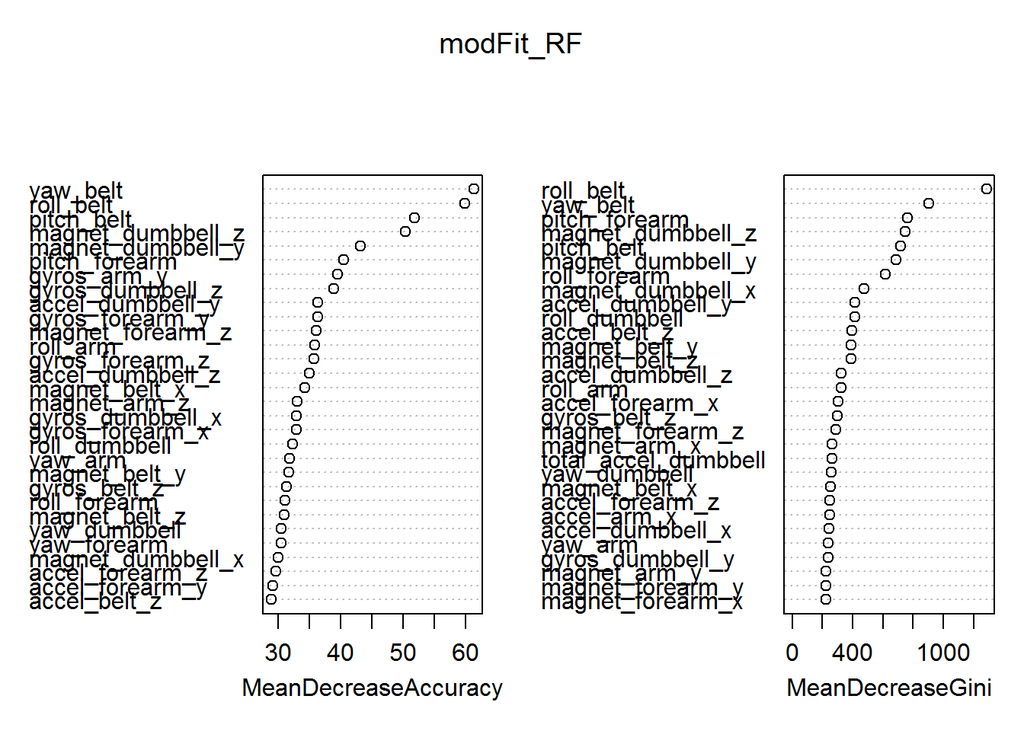

```r
varImpPlot(modFit_RF)
```

The rfcv function helps better see the point when having more predictors barely increases information gain.

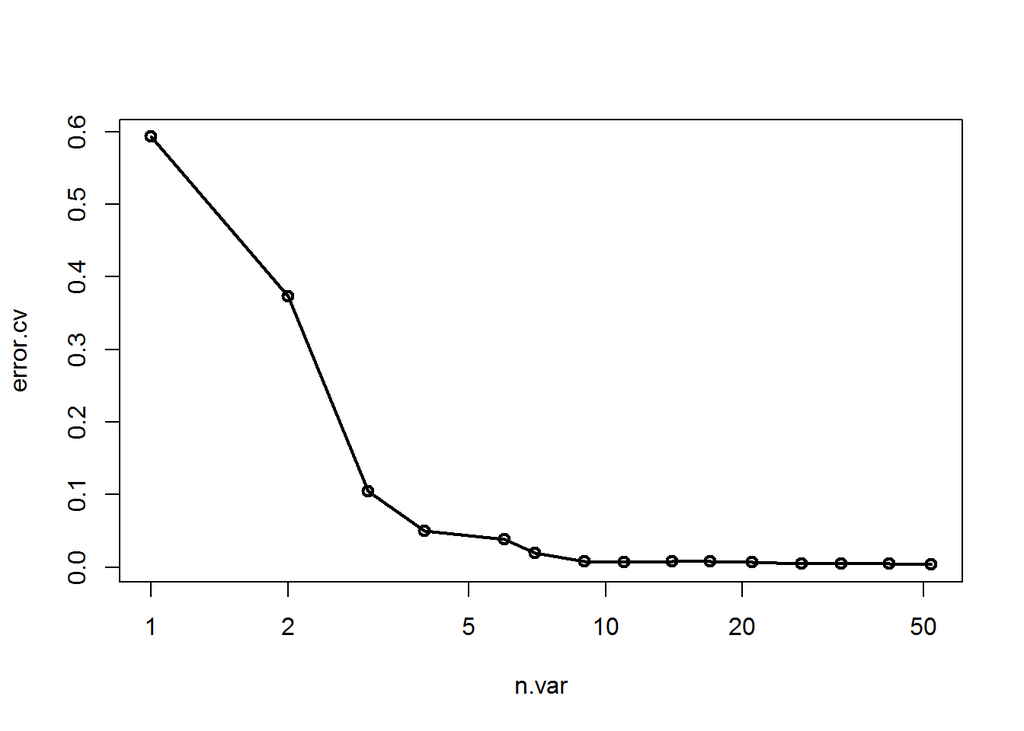

```r
lastPredColumn <- dim(filteredTraining)[2] - 1
result <- rfcv(filteredTraining[1:lastPredColumn], filteredTraining$classe, cv.fold=5, step=0.8)
with(result, plot(n.var, error.cv, log="x", type="o", lwd=2))
```

```r
result$error.cv
```

```
##          52          42          33          27          21          17
## 0.003669351 0.004586688 0.004637652 0.005147284 0.006523290 0.007644481
##          14          11           9           7           6           4
## 0.007695444 0.006880033 0.008154113 0.020079503 0.038681072 0.050096830
##           3           2           1
## 0.104525533 0.372795841 0.592803996
```

```r
smTraining <- filteredTraining[ , c("yaw_belt", "roll_belt", "pitch_belt", "magnet_dumbbell_z", "gyros_arm_y", "magnet_dumbbell_y", "pitch_forearm", "accel_dumbbell_y", "magnet_forearm_z", "classe")]
smTesting <- filteredTesting[ , c("yaw_belt", "roll_belt", "pitch_belt", "magnet_dumbbell_z", "gyros_arm_y", "magnet_dumbbell_y", "pitch_forearm", "accel_dumbbell_y", "magnet_forearm_z")]
```

I train a single decision tree on the 9 variables and I print its dendogram.

```r
modFit <- train(classe ~ .,method="rpart",data=smTraining)
```

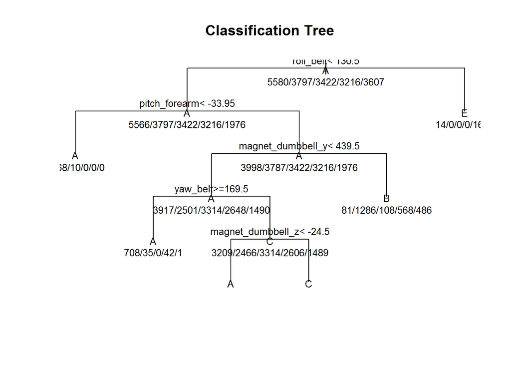

```r
plot(modFit$finalModel, uniform=TRUE, main="Classification Tree")
text(modFit$finalModel, use.n=TRUE, all=TRUE, cex=.8)
```

```r
predict(modFit,newdata=smTesting)
```

```
##  [1] A A C C C C C C A A C C C A C C C A A C
## Levels: A B C D E
```

```r
modFit
```

```
## CART
##
## 19622 samples
##     9 predictor
##     5 classes: 'A', 'B', 'C', 'D', 'E'
##
## No pre-processing
## Resampling: Bootstrapped (25 reps)
##
## Summary of sample sizes: 19622, 19622, 19622, 19622, 19622, 19622, ...
##
## Resampling results across tuning parameters:
##
##   cp      Accuracy  Kappa   Accuracy SD  Kappa SD
##   0.0376  0.528     0.3973  0.0540       0.0895
##   0.0429  0.424     0.2254  0.0696       0.1243
##   0.1152  0.335     0.0751  0.0416       0.0626
##
## Accuracy was used to select the optimal model using  the largest value.
## The final value used for the model was cp = 0.03763709.
```